# 데이터마이닝의 이론과 실제 중간고사 연습문제

# p_value

```r
null_dist_f %>%
  get_p_value(obs_stat = f_cal,
              direction = "greater") %>%
  print()
```

```
## # A tibble: 1 x 1
##   p_value
##     <dbl>
## 1   0.003
```

> alternative는 two.sided, greater, less 3개의 값이 있다. default 값은 two.sided 이며, 이는 주어진 평균과 샘플이 단지 다르다는 것을 대립가설(H1)으로 두고자 할 때 사용되며 greater는 오로지 샘플이 주어진 평균보다 크다는 것을 대립가설(H1)을 두고자 할때, less는 작다는 것을 대립가설로 두고자 할 때 사용된다.

# 부록: 이분산(levene_test < 0.05) 일때 Welch’s ANOVA test

```r
edu_tb %>%
  welch_anova_test(비교과운영 ~ 학년)
```

```
## # A tibble: 1 x 7
##   .y.            n statistic   DFn   DFd       p method
## * <chr>      <int>     <dbl> <dbl> <dbl>   <dbl> <chr>
## 1 비교과운영   257      6.63     3  133. 0.00033 Welch ANOVA
```

```r
edu_tb %>%
  pairwise_t_test(비교과운영 ~ 학년,
                     pool.sd = FALSE,      # 등분산 가정 안함
                     p.adj="bonferroni")
```

```
## # A tibble: 6 x 10
##   .y.     group1 group2    n1    n2 statistic    df       p   p.adj p.adj.signif
## * <chr>   <chr>  <chr>  <int> <int>     <dbl> <dbl>   <dbl>   <dbl> <chr>
## 1 비교과~ 1학년  2학년     45    85    -2.08   114. 3.9 e-2 2.36e-1 ns
## 2 비교과~ 1학년  3학년     45    61    -4.12   102. 7.65e-5 4.59e-4 ***
## 3 비교과~ 1학년  4학년     45    66    -3.46   106. 7.79e-4 5   e-3 **
## 4 비교과~ 2학년  3학년     85    61    -2.12   137. 3.6 e-2 2.15e-1 ns
## 5 비교과~ 2학년  4학년     85    66    -1.44   144. 1.51e-1 9.06e-1 ns
## 6 비교과~ 3학년  4학년     61    66     0.668  125. 5.06e-1 1   e+0 ns
```

# 부록: 정규분포 가정 문제가 있으면 shapiro_test < 0.05

# 비모수통계분석 Kruskal Wallis H test

```r
edu_tb %>%
  kruskal_test(비교과운영 ~ 학년)
```

```
## # A tibble: 1 x 6
##   .y.            n statistic    df       p method
## * <chr>      <int>     <dbl> <int>   <dbl> <chr>
## 1 비교과운영   257      16.0     3 0.00113 Kruskal-Wallis
```

# 비모수 다중비교 Dunn test

```r
edu_tb %>%
  dunn_test(비교과운영 ~ 학년)
```

```
## # A tibble: 6 x 9
##   .y.        group1 group2    n1    n2 statistic        p   p.adj p.adj.signif
## * <chr>      <chr>  <chr>  <int> <int>     <dbl>    <dbl>   <dbl> <chr>
## 1 비교과운영 1학년  2학년     45    85     1.88  0.0598   0.179   ns
## 2 비교과운영 1학년  3학년     45    61     3.58  0.000337 0.00202 **
## 3 비교과운영 1학년  4학년     45    66     3.24  0.00120  0.00599 **
## 4 비교과운영 2학년  3학년     85    61     2.13  0.0332   0.133   ns
## 5 비교과운영 2학년  4학년     85    66     1.70  0.0888   0.179   ns
## 6 비교과운영 3학년  4학년     61    66    -0.441 0.659    0.659   ns
```

# 연습문제2 K대학에서는 재학생(1)과 교원(2)을 대상으로 교육과정에 대한 현황조사를 실시하였다. 종합점수가 재학생과 교원이 차이가 있는가?

# 1.기본 package 설정

# 1.1 library 로드

```r
library(tidyverse)
library(tidymodels)
library(rstatix)
library(skimr)
```

# 2.데이터 불러오기

```r
edu_tb <- read_csv('data2.csv',
                   col_names = TRUE,
                   locale=locale('ko', encoding='euc-kr'), # 한글
                   na=".") %>%
  round(2) %>%                 # 소수점 2자리로 반올림
  mutate_if(is.character, as.factor) %>%
  mutate(구분 = factor(구분,
                       levels=c(1,2),
                       labels=c("재학생","교원")))
str(edu_tb)
```

```
## tibble [100 x 3] (S3: tbl_df/tbl/data.frame)
##  $ 번호: num [1:100] 42 10 23 31 20 29 44 45 35 18 ...
##  $ 구분: Factor w/ 2 levels "재학생","교원": 1 1 1 1 1 1 1 1 1 1 ...
##  $ 종합: num [1:100] 0 5 70.8 71.6 71.7 71.7 73.3 73.3 78.3 79.1 ...
```

```r
edu_tb
```

```
## # A tibble: 100 x 3
##     번호 구분    종합
##    <dbl> <fct>  <dbl>
##  1    42 재학생   0
##  2    10 재학생   5
##  3    23 재학생  70.8
##  4    31 재학생  71.6
##  5    20 재학생  71.7
##  6    29 재학생  71.7
##  7    44 재학생  73.3
##  8    45 재학생  73.3
##  9    35 재학생  78.3
## 10    18 재학생  79.1
## # ... with 90 more rows
```

# 3.기술통계분석

```r
skim(edu_tb)
```

Data summary

| Name | edu_tb |
| --- | --- |
| Number of rows | 100 |
| Number of columns | 3 |
| _______________________ |  |
| Column type frequency: |  |
| factor | 1 |
| numeric | 2 |
| ________________________ |  |
| Group variables | None |

**Variable type: factor**

| skim_variable | n_missing | complete_rate | ordered | n_unique | top_counts |
| --- | --- | --- | --- | --- | --- |
| 구분 | 0 | 1 | FALSE | 2 | 재학생: 50, 교원: 50 |

**Variable type: numeric**

| skim_variable | n_missing | complete_rate | mean | sd | p0 | p25 | p50 | p75 | p100 | hist |
| --- | --- | --- | --- | --- | --- | --- | --- | --- | --- | --- |
| 번호 | 0 | 1 | 50.50 | 29.01 | 1 | 25.75 | 50.5 | 75.25 | 100.0 | ▇▇▇▇▇ |
| 종합 | 0 | 1 | 73.54 | 16.05 | 0 | 66.60 | 73.3 | 84.32 | 98.3 | ▁▁▂▇▇ |

```r
edu_tb %>%
  group_by(구분) %>%
  get_summary_stats(종합)
```

```
## # A tibble: 2 x 14
##   구분   variable     n   min   max median    q1    q3   iqr   mad  mean    sd
##   <fct>  <chr>    <dbl> <dbl> <dbl>  <dbl> <dbl> <dbl> <dbl> <dbl> <dbl> <dbl>
## 1 재학생 종합        50   0    95.8     70  62.0  78.9  16.9  12.5  68.6  17.6
## 2 교원   종합        50  39.1  98.3     80  70.2  87.5  17.3  13.6  78.5  12.7
## # ... with 2 more variables: se <dbl>, ci <dbl>
```

# 4.그래프 그리기(박스그래프,히스토그램)

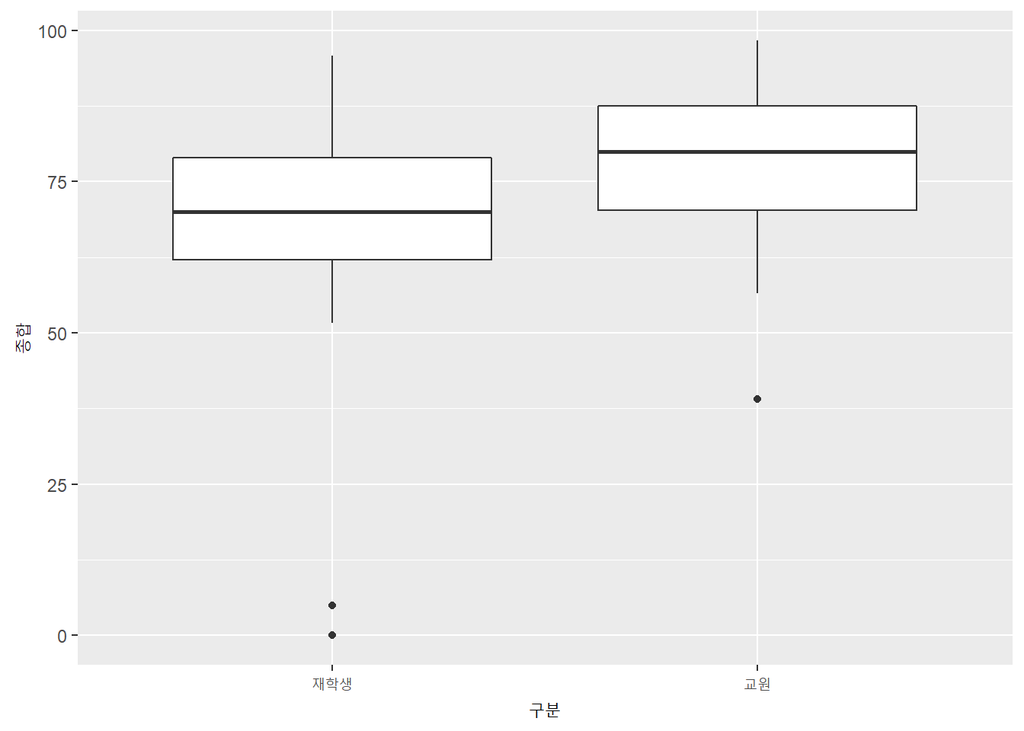

```r
edu_tb %>%
  ggplot(mapping = aes(x = 구분,
                       y = 종합)) +
  geom_boxplot() +
  labs(y = "종합")
```

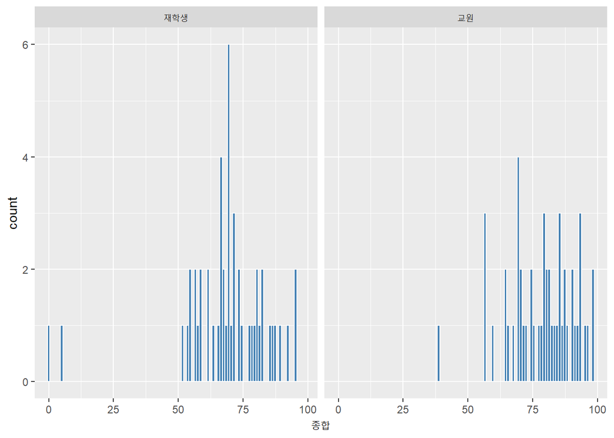

```r
edu_tb %>%
  ggplot(mapping = aes(x = 종합)) +
  geom_histogram(bins = 100,               # binwidth=1,000: 값차이
                 color = "white",
                 fill = "steelblue") +
  facet_wrap(~ 구분)                   # 그룹별 분리
```

# 5.이상치 제거

# 이상치 확인

```r
edu_tb %>%
  group_by(구분) %>%
  identify_outliers(종합)
```

```
## # A tibble: 3 x 5
##   구분    번호  종합 is.outlier is.extreme
##   <fct>  <dbl> <dbl> <lgl>      <lgl>
## 1 재학생    42   0   TRUE       TRUE
## 2 재학생    10   5   TRUE       TRUE
## 3 교원      70  39.1 TRUE       FALSE
```

# 이상치 제거

```r
edu_tb <- edu_tb %>%
  filter(!(구분 == "재학생" & 종합 <= 5 )) %>%
  filter(!(구분 == "교원" & 종합 <= 39.1 ))
```

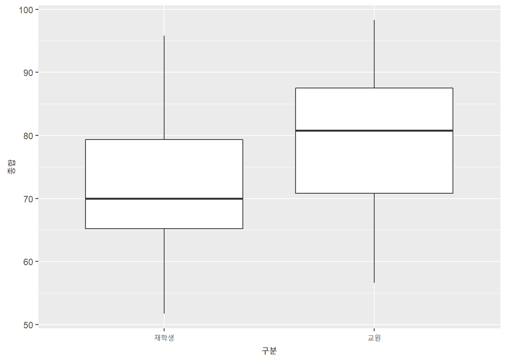

```r
edu_tb %>%
  ggplot(mapping = aes(x = 구분,
                       y = 종합)) +
  geom_boxplot() +
  labs(y = "종합")
```

# 6.정규분포 검정, p값이 0.05 보다 크므로 정규분포를 따른다.

```r
edu_tb %>%
  group_by(구분) %>%
  shapiro_test(종합)
```

```
## # A tibble: 2 x 4
##   구분   variable statistic     p
##   <fct>  <chr>        <dbl> <dbl>
## 1 재학생 종합         0.969 0.227
## 2 교원   종합         0.967 0.192
```

# 7.등분산 검정

```r
edu_tb %>%
  levene_test(종합 ~ 구분)
```

```
## # A tibble: 1 x 4
##     df1   df2 statistic     p
##   <int> <int>     <dbl> <dbl>
## 1     1    95     0.231 0.632
```

```r
# 0.05이므로 등분산 성립
```

# 8.등분산 t-검정

# two-sided test: alternative = c(“two.sided”)

# right-sided test: alternative = c(“greater”)

# left-sided test: alternative = c(“less”)

# 등분산이면 var.equal=TRUE, 이분산이면 var.equal=FALSE

```r
edu_tb %>%
  t_test(formula = 종합 ~ 구분,
         comparisons = c("재학생", "교원"),
         paired = FALSE,
         var.equal = TRUE,
         alternative = "two.sided", # 양측 검정 (재학생,교원->두 집단의 차이만 검정 ) <-> 단측 검정 ( 모수의 평균으로 비교 )https://m.blog.naver.com/mykepzzang/220886418140
         detailed = TRUE)
```

```
## # A tibble: 1 x 15
##   estimate estimate1 estimate2 .y.   group1 group2    n1    n2 statistic       p
## *    <dbl>     <dbl>     <dbl> <chr> <chr>  <chr>  <int> <int>     <dbl>   <dbl>
## 1    -8.01      71.3      79.3 종합  재학생 교원      48    49     -3.46 8.04e-4
## # ... with 5 more variables: df <dbl>, conf.low <dbl>, conf.high <dbl>,
## #   method <chr>, alternative <chr>
```

# Cohen’s d(effect size)

# 0.2 (small effect), 0.5 (moderate effect) and 0.8 (large effect)

```r
edu_tb %>%
  cohens_d(formula = 종합 ~ 구분,
           var.equal = TRUE)
```

```
## # A tibble: 1 x 7
##   .y.   group1 group2 effsize    n1    n2 magnitude
## * <chr> <chr>  <chr>    <dbl> <int> <int> <ord>
## 1 종합  재학생 교원    -0.703    48    49 moderate
```

# 9.추론(infer)을 이용한 가설검정 및 그래프

# 9.1 표본평균(x)을 이용한 검정그래프

# 표본평균(x) 계산

```r
x_bar <- edu_tb %>%
  specify(formula = 종합 ~ 구분) %>%   # hypothesize 없음
  calculate(stat = "diff in means",         # diff in means 변경, 재학생,교원의 차이
            order= c("재학생", "교원")) %>%
  print()
```

```
## Response: 종합 (numeric)
## Explanatory: 구분 (factor)
## # A tibble: 1 x 1
##    stat
##   <dbl>
## 1 -8.01
```

# Bootstrapping을 이용한 귀무가설 분포 생성

```r
set.seed(123)
null_dist_x <- edu_tb %>%
  specify(formula = 종합 ~ 구분) %>%
  hypothesize(null = "independence") %>% # 차이가 있는 가 확인 할때 independence
  generate(reps = 1000, type = "permute") %>%
  calculate(stat = "diff in means",
            order= c("재학생", "교원")) %>%
  print()
```

```
## Response: 종합 (numeric)
## Explanatory: 구분 (factor)
## Null Hypothesis: independence
## # A tibble: 1,000 x 2
##    replicate   stat
##        <int>  <dbl>
##  1         1 -0.836
##  2         2  1.61
##  3         3 -0.914
##  4         4  2.03
##  5         5 -0.432
##  6         6 -2.34
##  7         7 -2.25
##  8         8 -3.36
##  9         9  0.125
## 10        10  4.79
## # ... with 990 more rows
```

# 신뢰구간 생성

```r
null_dist_ci <- null_dist_x %>%
  get_ci(level = 0.95,
         type = "percentile") %>%
  print()
```

```
## # A tibble: 1 x 2
##   lower_ci upper_ci
##      <dbl>    <dbl>
## 1    -4.82     4.79
```

# 그래프 그리기

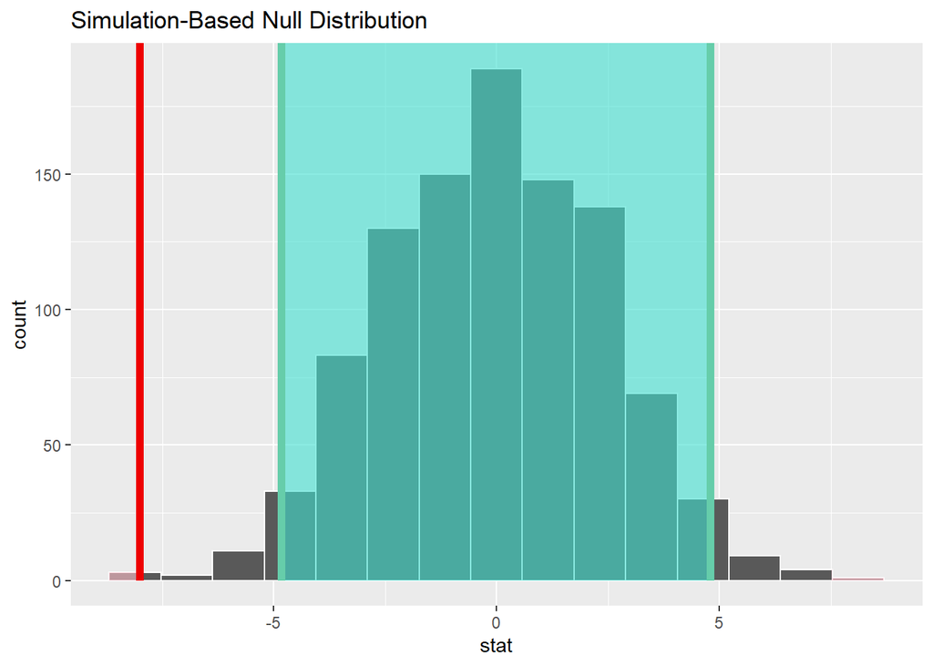

```r
null_dist_x %>%
  visualize() +                                       # method 없음
  shade_p_value(obs_stat = x_bar,
                direction = "two-sided") +            # x_bar
  shade_confidence_interval(endpoints = null_dist_ci) # CI
```

# p_value : 0.05 보다 작으므로 교원과 재학생들의 종합점수가 차이가 있다.

```r
null_dist_x %>%
  get_p_value(obs_stat = x_bar,
              direction = "two-sided") %>%
  print()
```

```
## # A tibble: 1 x 1
##   p_value
##     <dbl>
## 1   0.002
```

# 9.2 t값을 이용한 검정그래프

# t_cal 계산

```r
t_cal <- edu_tb %>%
  specify(formula = 종합 ~ 구분) %>% # hypothesize 없음
  calculate(stat = "t",  # 두 집단은 t 검정 사용
            order= c("재학생", "교원")) %>%
  print()
```

```
## Response: 종합 (numeric)
## Explanatory: 구분 (factor)
## # A tibble: 1 x 1
##    stat
##   <dbl>
## 1 -3.46
```

# Bootstrapping을 이용한 귀무가설 분포 생성

```r
set.seed(123)
null_dist_t <- edu_tb %>%
  specify(formula = 종합 ~ 구분) %>%
  hypothesize(null = "independence") %>%
  generate(reps = 1000, type = "permute") %>%
  calculate(stat = "t",
            order= c("재학생", "교원")) %>%
  print()
```

```
## Response: 종합 (numeric)
## Explanatory: 구분 (factor)
## Null Hypothesis: independence
## # A tibble: 1,000 x 2
##    replicate    stat
##        <int>   <dbl>
##  1         1 -0.341
##  2         2  0.657
##  3         3 -0.373
##  4         4  0.829
##  5         5 -0.176
##  6         6 -0.959
##  7         7 -0.924
##  8         8 -1.38
##  9         9  0.0508
## 10        10  1.99
## # ... with 990 more rows
```

# 신뢰구간 생성

```r
null_dist_ci <- null_dist_t %>%
  get_ci(level = 0.95,
         type = "percentile") %>%
  print()
```

```
## # A tibble: 1 x 2
##   lower_ci upper_ci
##      <dbl>    <dbl>
## 1    -2.00     1.99
```

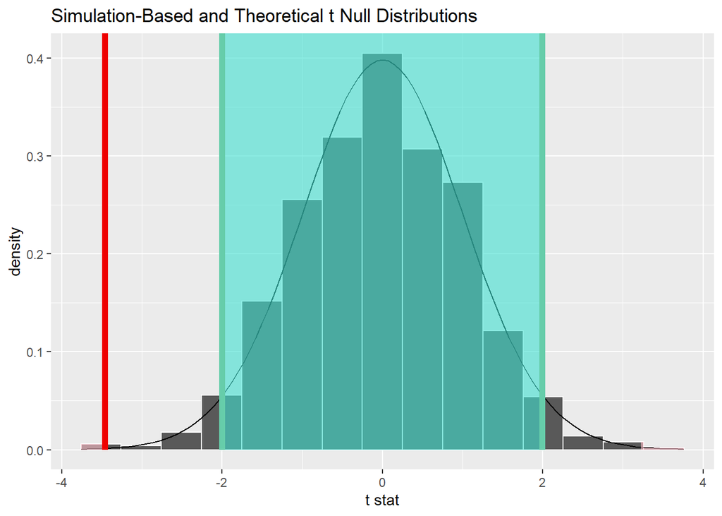

```r
null_dist_t %>%
  visualize(method = "both") +           #method = "both": 이론분포+boot분포
  shade_p_value(obs_stat = t_cal,
                direction = "two-sided") +
  shade_confidence_interval(endpoints = null_dist_ci)
```

# 부록. 비모수통계분석

# 정규분포검정 p < 0.05일 때 비모수 wilcox.test로 분석

```r
edu_tb %>%
  wilcox_test(formula = 종합 ~ 구분,
              alternative = "two.sided")
```

```
## # A tibble: 1 x 7
##   .y.   group1 group2    n1    n2 statistic        p
## * <chr> <chr>  <chr>  <int> <int>     <dbl>    <dbl>
## 1 종합  재학생 교원      48    49       718 0.000958
```

## 연습문제3

## K대학에서는 재학생 만족도 조사를 실시하였다.

## 재학생 만족도가 50점이라고 할 수 있는가?

# 1.기본 package 설정

# 1.1 library 로드

```r
library(tidyverse)
library(tidymodels)
library(rstatix)
library(skimr)
```

# 2.데이터 불러오기

```r
sat_tb <- read_csv('data3.csv',
                   col_names = TRUE,
                   locale=locale('ko', encoding='euc-kr'), # 한글
                   na=".") %>%
  round(2) %>%                  # 소수점 2자리로 반올림
  mutate_if(is.character, as.factor)
str(sat_tb)
```

```
## tibble [200 x 2] (S3: tbl_df/tbl/data.frame)
##  $ no   : num [1:200] 1 2 3 4 5 6 8 9 10 11 ...
##  $ satis: num [1:200] 33.8 39.3 41.8 59.3 41.8 31.3 18.7 43.6 43.1 50.4 ...
```

```r
glimpse(sat_tb)
```

```
## Rows: 200
## Columns: 2
## $ no    <dbl> 1, 2, 3, 4, 5, 6, 8, 9, 10, 11, 13, 14, 16, 17, 18, 19, 20, 21, ~
## $ satis <dbl> 33.8, 39.3, 41.8, 59.3, 41.8, 31.3, 18.7, 43.6, 43.1, 50.4, 46.7~
```

```r
sat_tb
```

```
## # A tibble: 200 x 2
##       no satis
##    <dbl> <dbl>
##  1     1  33.8
##  2     2  39.3
##  3     3  41.8
##  4     4  59.3
##  5     5  41.8
##  6     6  31.3
##  7     8  18.7
##  8     9  43.6
##  9    10  43.1
## 10    11  50.4
## # ... with 190 more rows
```

# 3.기본통계치 확인

```r
skim(sat_tb)
```

Data summary

| Name | sat_tb |
| --- | --- |
| Number of rows | 200 |
| Number of columns | 2 |
| _______________________ |  |
| Column type frequency: |  |
| numeric | 2 |
| ________________________ |  |
| Group variables | None |

**Variable type: numeric**

| skim_variable | n_missing | complete_rate | mean | sd | p0 | p25 | p50 | p75 | p100 | hist |
| --- | --- | --- | --- | --- | --- | --- | --- | --- | --- | --- |
| no | 0 | 1 | 112.82 | 64.58 | 1.0 | 56.75 | 113.5 | 168.25 | 222.0 | ▇▇▇▇▇ |
| satis | 0 | 1 | 49.98 | 17.17 | 16.2 | 39.45 | 48.4 | 59.32 | 96.3 | ▃▇▇▂▂ |

```r
sat_tb %>%
  get_summary_stats(satis)
```

```
## # A tibble: 1 x 13
##   variable     n   min   max median    q1    q3   iqr   mad  mean    sd    se
##   <chr>    <dbl> <dbl> <dbl>  <dbl> <dbl> <dbl> <dbl> <dbl> <dbl> <dbl> <dbl>
## 1 satis      200  16.2  96.3   48.4  39.4  59.3  19.9  15.0  50.0  17.2  1.21
## # ... with 1 more variable: ci <dbl>
```

# 4.그래프 그리기(박스그래프,히스토그램)

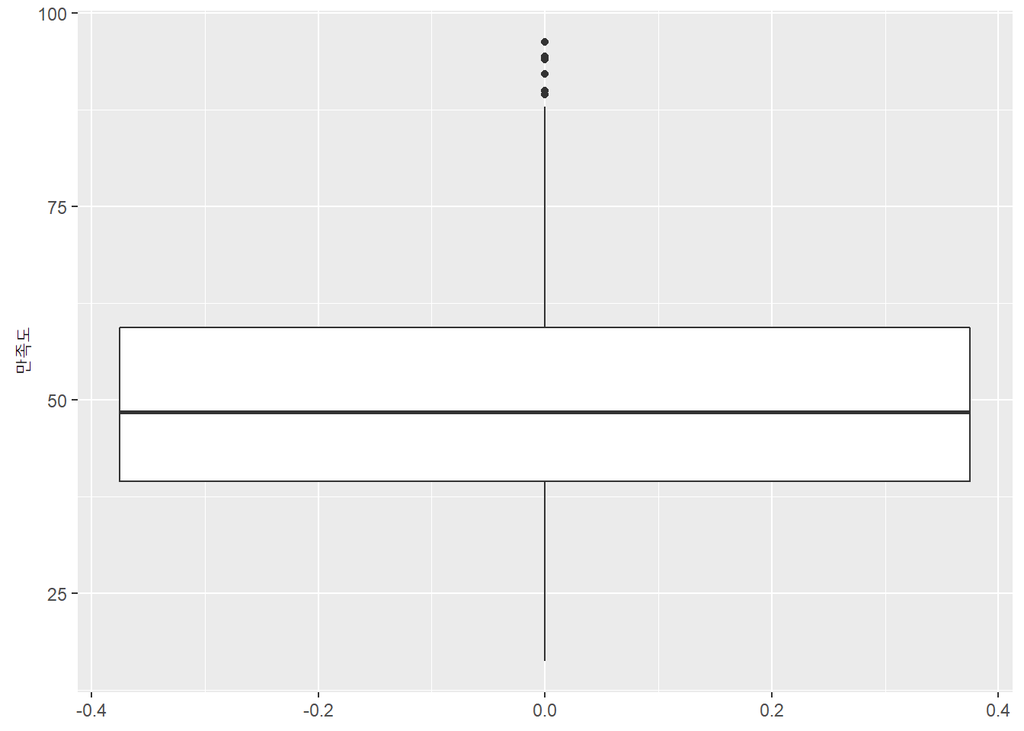

```r
sat_tb %>%
  ggplot(aes(y = satis)) +
  geom_boxplot() +
  labs(y = "만족도")
```

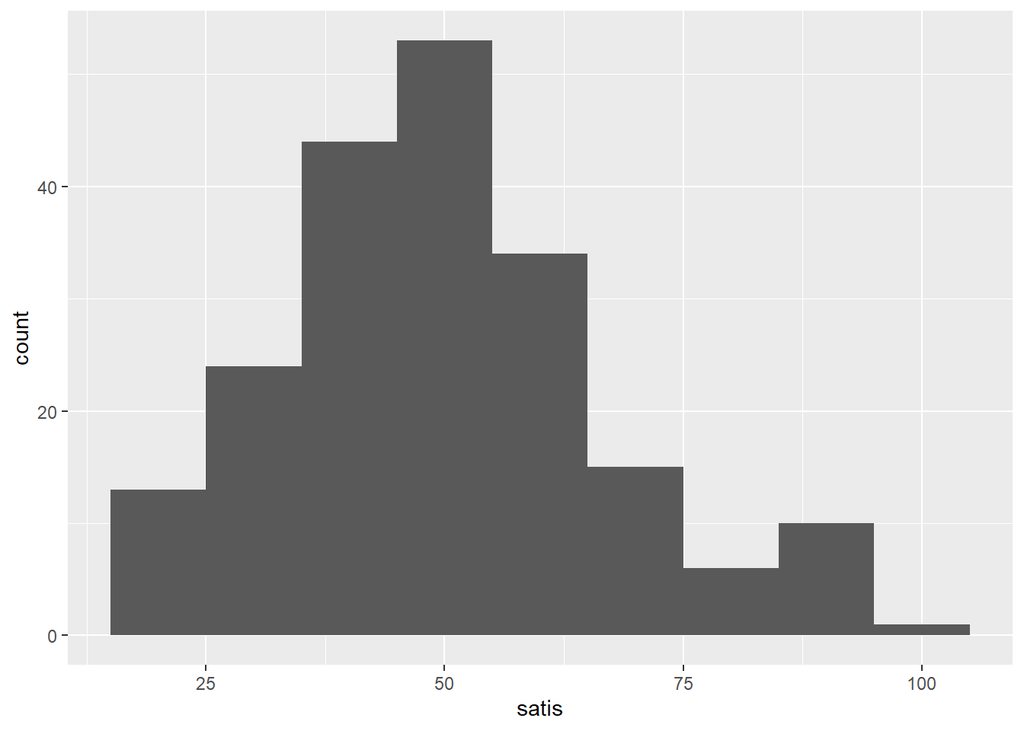

```r
sat_tb %>%
  ggplot(mapping = aes(x = satis)) +
  geom_histogram(binwidth = 10) +
  coord_cartesian()
```

#coord_cartesian(xlim = c(0, 167), ylim = c(0, 114))

# 5.이상치 제거

# 이상치 확인

```r
sat_tb %>%
  identify_outliers(satis)
```

```
## # A tibble: 7 x 4
##      no satis is.outlier is.extreme
##   <dbl> <dbl> <lgl>      <lgl>
## 1    27  96.3 TRUE       FALSE
## 2    88  94.1 TRUE       FALSE
## 3   112  89.5 TRUE       FALSE
## 4   119  90   TRUE       FALSE
## 5   122  94.4 TRUE       FALSE
## 6   209  92.1 TRUE       FALSE
## 7   219  94   TRUE       FALSE
```

# 이상치 제거

```r
sat_tb <- sat_tb %>%
  filter(!(satis >= 86))
```

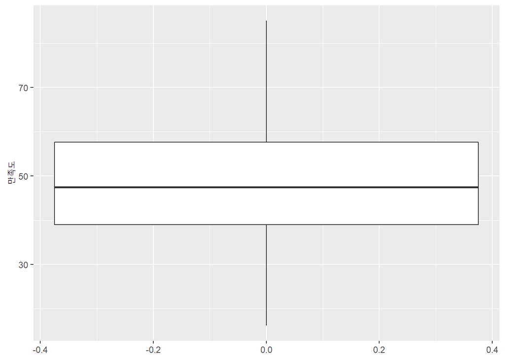

```r
sat_tb %>%
  ggplot(aes(y = satis)) +
  geom_boxplot() +
  labs(y = "만족도")
```

# 6.정규분포 검정 ,0.05보다 크므로 정규분포 만족

```r
sat_tb %>%
  shapiro_test(satis)
```

```
## # A tibble: 1 x 3
##   variable statistic     p
##   <chr>        <dbl> <dbl>
## 1 satis        0.990 0.177
```

# 7.통계분석

# two-sided test: alternative = c(“two.sided”)

# right-sided test: alternative = c(“greater”)

# left-sided test: alternative = c(“less”)

```r
sat_tb %>%
  t_test(formula = satis ~ 1,
         alternative = "two.sided",  # two.sided 이며, 이는 주어진 평균(50)과 샘플이 단지 다르다는 것을 대립가설(H1)으로 두고자 할 때 사용되며
         mu = 50.0,
         conf.level = 0.95,
         detailed = TRUE)
```

```
## # A tibble: 1 x 12
##   estimate .y.   group1 group2       n statistic      p    df conf.low conf.high
## *    <dbl> <chr> <chr>  <chr>    <int>     <dbl>  <dbl> <dbl>    <dbl>     <dbl>
## 1     48.0 satis 1      null mo~   191     -1.83 0.0683   190     45.9      50.1
## # ... with 2 more variables: method <chr>, alternative <chr>
```

# Cohen’s d(effect size)

# 0.2 (small effect), 0.5 (moderate effect) and 0.8 (large effect)

```r
sat_tb %>%
  cohens_d(formula = satis ~ 1,
           mu = 50.0)
```

```
## # A tibble: 1 x 6
##   .y.   group1 group2     effsize     n magnitude
## * <chr> <chr>  <chr>        <dbl> <int> <ord>
## 1 satis 1      null model  -0.133   191 negligible
```

# negligible: 무시할수 있을만큼 차이가 없다.

# 8.추론(infer)을 이용한 가설검정 및 그래프

# p.21 설명

# 8.1 표본평균(x)을 이용한 검정그래프

# 표본평균(x) 계산

```r
x_bar <- sat_tb %>%
  specify(response = satis) %>%    # hypothesize 없음
  calculate(stat = "mean") %>%      # stat = "mean"
  print()
```

```
## Response: satis (numeric)
## # A tibble: 1 x 1
##    stat
##   <dbl>
## 1  48.0
```

# Bootstrapping을 이용한 귀무가설 분포 생성

```r
set.seed(123)
null_dist_x <- sat_tb %>%
  specify(response = satis) %>%
  hypothesize(null = "point",  # 평균의 비교 : point
              mu = 50) %>%
  generate(reps = 1000,
           type = "bootstrap") %>%
  calculate(stat = "mean") %>%
  print()
```

```
## Response: satis (numeric)
## Null Hypothesis: point
## # A tibble: 1,000 x 2
##    replicate  stat
##        <int> <dbl>
##  1         1  49.4
##  2         2  50.3
##  3         3  50.0
##  4         4  49.5
##  5         5  49.3
##  6         6  50.7
##  7         7  50.9
##  8         8  51.1
##  9         9  48.6
## 10        10  51.6
## # ... with 990 more rows
```

# 신뢰구간 생성

```r
null_dist_ci <- null_dist_x %>%
  get_ci(level = 0.95,
         type = "percentile") %>%
  print()
```

```
## # A tibble: 1 x 2
##   lower_ci upper_ci
##      <dbl>    <dbl>
## 1     47.9     52.1
```

# 그래프 그리기

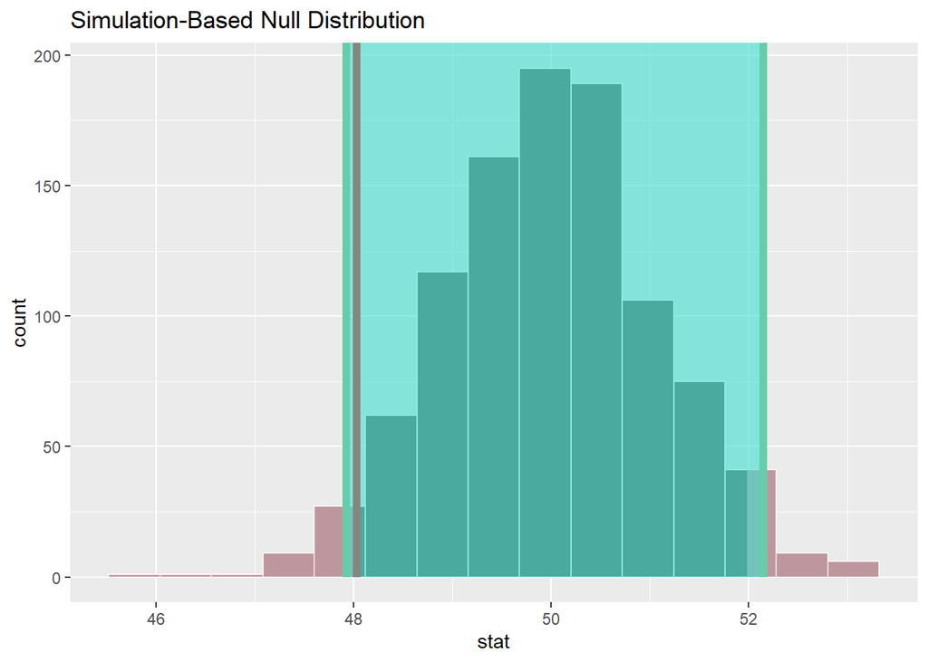

```r
null_dist_x %>%
  visualize() +                                       # method 없음
  shade_p_value(obs_stat = x_bar,
                direction = "two-sided") +            # x_bar
  shade_confidence_interval(endpoints = null_dist_ci) # CI
```

# p_value

```r
null_dist_x %>%
  get_p_value(obs_stat = x_bar,
              direction = "two-sided") %>%
  print()
```

```
## # A tibble: 1 x 1
##   p_value
##     <dbl>
## 1   0.066
```

# 0.05 보다 크므로 귀무가설 성립 -> 평균 50점과 차이가 없다.

# 8.2 t값을 이용한 검정그래프

# t_cal 계산

```r
t_cal <- sat_tb %>%
  specify(response = satis) %>%
  hypothesize(null = "point",         # hypothesize 필요
              mu = 50) %>%
  calculate(stat = "t") %>%           # stat = "t"
  print()
```

```
## Response: satis (numeric)
## Null Hypothesis: point
## # A tibble: 1 x 1
##    stat
##   <dbl>
## 1 -1.83
```

# Bootstrapping을 이용한 귀무가설 분포 생성

```r
set.seed(123)
null_dist_t <- sat_tb %>%
  specify(response = satis) %>%
  hypothesize(null = "point",
              mu = 50) %>%
  generate(reps = 1000,
           type = "bootstrap") %>%
  calculate(stat = "t") %>%
  print()
```

```
## Response: satis (numeric)
## Null Hypothesis: point
## # A tibble: 1,000 x 2
##    replicate    stat
##        <int>   <dbl>
##  1         1 -0.540
##  2         2  0.299
##  3         3  0.0284
##  4         4 -0.543
##  5         5 -0.675
##  6         6  0.653
##  7         7  0.783
##  8         8  1.08
##  9         9 -1.42
## 10        10  1.49
## # ... with 990 more rows
```

# 신뢰구간 생성

```r
null_dist_ci <- null_dist_t %>%
  get_ci(level = 0.95,
         type = "percentile") %>%
  print()
```

```
## # A tibble: 1 x 2
##   lower_ci upper_ci
##      <dbl>    <dbl>
## 1    -1.99     1.94
```

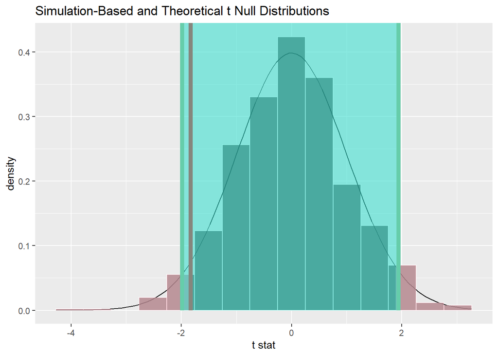

```r
null_dist_t %>%
  visualize(method = "both") +           #method = "both": 이론분포+boot분포
  shade_p_value(obs_stat = t_cal,
                direction = "two-sided") +
  shade_confidence_interval(endpoints = null_dist_ci)
```

# 연습문제4

# 다음은 호흡과 뇌파와의 관계를 연구한 자료이다.

# 총 4개 채널이 있는데, 채널별로 알파파(al)와 베타파(be) 간에는 각각 차이가 있는가?

# Ch1의 알파타와 베타파의 차이를 검증하고, 나머지 변수도 해보세요.

# 1.기본 package 설정

```r
library(tidyverse)
library(tidymodels)
library(rstatix)
library(skimr)
```

# 2.데이터 불러오기

```r
brain_tb <- read_csv('data4.csv',
                     col_names = TRUE,
                     locale=locale('ko', encoding='euc-kr'), # 한글
                     na=".") %>%
  round(2) %>%                 # 소수점 2자리로 반올림
  mutate_if(is.character, as.factor)
str(brain_tb)
```

```
## tibble [144 x 8] (S3: tbl_df/tbl/data.frame)
##  $ ch1al: num [1:144] 0.03 0.05 0.05 0.01 0.04 0.03 0.02 0.04 0.03 0.03 ...
##  $ ch2al: num [1:144] 0.03 0.04 0.02 0.01 0.04 0.03 0.02 0.05 0.03 0.05 ...
##  $ ch3al: num [1:144] 0.02 0.07 0.06 0.02 0.05 0.03 0.02 0.05 0.02 0.08 ...
##  $ ch4al: num [1:144] 0.02 0.07 0.06 0.02 0.06 0.02 0.02 0.03 0.03 0.08 ...
##  $ ch1be: num [1:144] 0.18 0.09 0.13 0.08 0.18 0.17 0.17 0.18 0.08 0.1 ...
##  $ ch2be: num [1:144] 0.14 0.14 0.15 0.09 0.13 0.28 0.17 0.16 0.1 0.1 ...
##  $ ch3be: num [1:144] 0.14 0.12 0.14 0.07 0.14 0.17 0.19 0.18 0.07 0.13 ...
##  $ ch4be: num [1:144] 0.1 0.1 0.1 0.1 0.1 0.2 0.2 0.2 0.1 0.1 ...
```

```r
brain_tb
```

```
## # A tibble: 144 x 8
##    ch1al ch2al ch3al ch4al ch1be ch2be ch3be ch4be
##    <dbl> <dbl> <dbl> <dbl> <dbl> <dbl> <dbl> <dbl>
##  1  0.03  0.03  0.02  0.02  0.18  0.14  0.14   0.1
##  2  0.05  0.04  0.07  0.07  0.09  0.14  0.12   0.1
##  3  0.05  0.02  0.06  0.06  0.13  0.15  0.14   0.1
##  4  0.01  0.01  0.02  0.02  0.08  0.09  0.07   0.1
##  5  0.04  0.04  0.05  0.06  0.18  0.13  0.14   0.1
##  6  0.03  0.03  0.03  0.02  0.17  0.28  0.17   0.2
##  7  0.02  0.02  0.02  0.02  0.17  0.17  0.19   0.2
##  8  0.04  0.05  0.05  0.03  0.18  0.16  0.18   0.2
##  9  0.03  0.03  0.02  0.03  0.08  0.1   0.07   0.1
## 10  0.03  0.05  0.08  0.08  0.1   0.1   0.13   0.1
## # ... with 134 more rows
```

# long형으로 변형

```r
brain_tb_long <- brain_tb %>%
  select(ch1al, ch1be) %>% # 필요한 변수만 선택
  pivot_longer(c("ch1al","ch1be"), #c("1999, 2000")에러남
               names_to = "채널",
               values_to = "뇌파")
```

```r
tail(brain_tb_long)
```

```
## # A tibble: 6 x 2
##   채널   뇌파
##   <chr> <dbl>
## 1 ch1al  0.07
## 2 ch1be  0.09
## 3 ch1al  0.07
## 4 ch1be  0.14
## 5 ch1al  0.02
## 6 ch1be  0.15
```

# 차이 추가

```r
brain_tb <- brain_tb %>%
  mutate(차이 = ch1al-ch1be) # mutate -> 새로운 칼럼 생성

brain_tb
```

```
## # A tibble: 144 x 9
##    ch1al ch2al ch3al ch4al ch1be ch2be ch3be ch4be  차이
##    <dbl> <dbl> <dbl> <dbl> <dbl> <dbl> <dbl> <dbl> <dbl>
##  1  0.03  0.03  0.02  0.02  0.18  0.14  0.14   0.1 -0.15
##  2  0.05  0.04  0.07  0.07  0.09  0.14  0.12   0.1 -0.04
##  3  0.05  0.02  0.06  0.06  0.13  0.15  0.14   0.1 -0.08
##  4  0.01  0.01  0.02  0.02  0.08  0.09  0.07   0.1 -0.07
##  5  0.04  0.04  0.05  0.06  0.18  0.13  0.14   0.1 -0.14
##  6  0.03  0.03  0.03  0.02  0.17  0.28  0.17   0.2 -0.14
##  7  0.02  0.02  0.02  0.02  0.17  0.17  0.19   0.2 -0.15
##  8  0.04  0.05  0.05  0.03  0.18  0.16  0.18   0.2 -0.14
##  9  0.03  0.03  0.02  0.03  0.08  0.1   0.07   0.1 -0.05
## 10  0.03  0.05  0.08  0.08  0.1   0.1   0.13   0.1 -0.07
## # ... with 134 more rows
```

# 3.기술통계분석

```r
skim(brain_tb)
```

Data summary

| Name | brain_tb |
| --- | --- |
| Number of rows | 144 |
| Number of columns | 9 |
| _______________________ |  |
| Column type frequency: |  |
| numeric | 9 |
| ________________________ |  |
| Group variables | None |

**Variable type: numeric**

| skim_variable | n_missing | complete_rate | mean | sd | p0 | p25 | p50 | p75 | p100 | hist |
| --- | --- | --- | --- | --- | --- | --- | --- | --- | --- | --- |
| ch1al | 0 | 1 | 0.04 | 0.03 | 0.00 | 0.03 | 0.04 | 0.05 | 0.17 | ▇▇▂▁▁ |
| ch2al | 0 | 1 | 0.04 | 0.02 | 0.00 | 0.03 | 0.04 | 0.05 | 0.14 | ▂▇▂▁▁ |
| ch3al | 0 | 1 | 0.05 | 0.03 | 0.00 | 0.03 | 0.04 | 0.06 | 0.15 | ▅▇▂▁▁ |
| ch4al | 0 | 1 | 0.04 | 0.02 | 0.00 | 0.03 | 0.04 | 0.05 | 0.15 | ▆▇▁▁▁ |
| ch1be | 0 | 1 | 0.12 | 0.04 | 0.03 | 0.10 | 0.12 | 0.14 | 0.28 | ▃▇▅▁▁ |
| ch2be | 0 | 1 | 0.13 | 0.04 | 0.02 | 0.10 | 0.12 | 0.15 | 0.28 | ▂▇▆▂▁ |
| ch3be | 0 | 1 | 0.13 | 0.04 | 0.02 | 0.11 | 0.12 | 0.15 | 0.24 | ▁▂▇▂▁ |
| ch4be | 0 | 1 | 0.12 | 0.05 | 0.00 | 0.10 | 0.10 | 0.12 | 0.20 | ▁▁▇▁▃ |
| 차이 | 0 | 1 | -0.08 | 0.05 | -0.25 | -0.11 | -0.08 | -0.05 | 0.12 | ▁▃▇▁▁ |

```r
brain_tb %>%
  get_summary_stats(ch1be, ch1al, 차이)
```

```
## # A tibble: 3 x 13
##   variable     n   min   max median    q1     q3   iqr   mad   mean    sd    se
##   <chr>    <dbl> <dbl> <dbl>  <dbl> <dbl>  <dbl> <dbl> <dbl>  <dbl> <dbl> <dbl>
## 1 ch1al      144  0     0.17   0.04  0.03  0.053 0.023 0.015  0.044 0.025 0.002
## 2 ch1be      144  0.03  0.28   0.12  0.1   0.14  0.04  0.03   0.123 0.039 0.003
## 3 차이       144 -0.25  0.12  -0.08 -0.11 -0.05  0.06  0.044 -0.078 0.053 0.004
## # ... with 1 more variable: ci <dbl>
```

# 4.그래프 그리기(박스그래프,히스토그램)

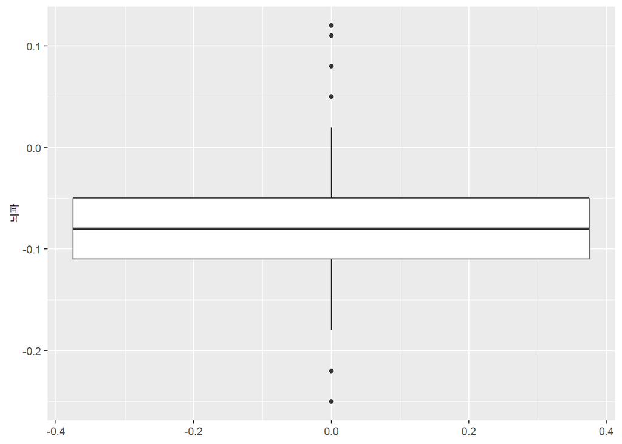

```r
brain_tb %>%
  ggplot(aes(y = 차이)) +
  geom_boxplot() +
  labs(y = "뇌파")
```

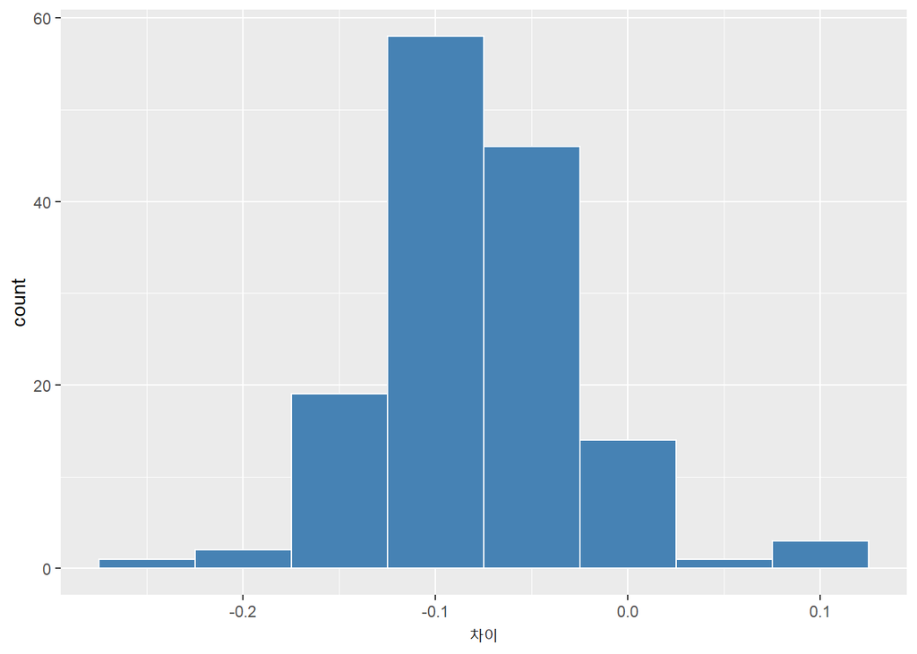

```r
brain_tb %>%
  ggplot(aes(x = 차이)) +
  geom_histogram(binwidth = 0.05,
                 color = "white",
                 fill = "steelblue")
```

# 5.이상치 제거

# 이상치 확인

```r
brain_tb %>%
  identify_outliers(차이)
```

```
## # A tibble: 6 x 11
##   ch1al ch2al ch3al ch4al ch1be ch2be ch3be ch4be  차이 is.outlier is.extreme
##   <dbl> <dbl> <dbl> <dbl> <dbl> <dbl> <dbl> <dbl> <dbl> <lgl>      <lgl>
## 1  0.15  0.06  0.12  0.11  0.03  0.11  0.08   0.1  0.12 TRUE       FALSE
## 2  0.17  0.14  0.15  0.15  0.06  0.08  0.06   0.1  0.11 TRUE       FALSE
## 3  0.03  0.04  0.01  0.01  0.28  0.18  0.19   0.2 -0.25 TRUE       FALSE
## 4  0.11  0.12  0.13  0.14  0.03  0.02  0.03   0    0.08 TRUE       FALSE
## 5  0.11  0.11  0.12  0.07  0.06  0.06  0.07   0.2  0.05 TRUE       FALSE
## 6  0     0     0     0     0.22  0.23  0.24   0.2 -0.22 TRUE       FALSE
```

# 이상치 제거

```r
brain_tb <- brain_tb %>%
  filter(!(차이 >= 0.01 | 차이 <= -0.22))
```

# 차이는 AND 값으로 ‘|’ 설정

# 6.정규분포 검정 ,0.05보다 크므로 정규분포 만족

```r
brain_tb %>%
  shapiro_test(차이)
```

```
## # A tibble: 1 x 3
##   variable statistic     p
##   <chr>        <dbl> <dbl>
## 1 차이         0.989 0.360
```

# aired-test에서는 Pre에서 Post를 뺀 값을 가지고 정규성 검정을 해야 된다.

# 알파 - 베타 = 차이로 검정해야한다.

# 7.paired t-검정

# two-sided test: alternative = c(“two.sided”)

# right-sided test: alternative = c(“greater”)

# left-sided test: alternative = c(“less”)

# paired = TRUE, paired t-test 정규분포를 따를때 사용 (p값 0.05 클때)

# 실험전과 후의 차이 또는 알파파와 베타파의 차이는 paired t-test 검정

```r
brain_tb_long %>%
  t_test(formula = 뇌파 ~ 채널,
         ref.group = "ch1al",
         paired = TRUE,
         alternative = "two.sided",
         detailed = TRUE)
```

```
## # A tibble: 1 x 13
##   estimate .y.   group1 group2    n1    n2 statistic        p    df conf.low
## *    <dbl> <chr> <chr>  <chr>  <int> <int>     <dbl>    <dbl> <dbl>    <dbl>
## 1  -0.0785 뇌파  ch1al  ch1be    144   144     -17.9 2.98e-38   143  -0.0872
## # ... with 3 more variables: conf.high <dbl>, method <chr>, alternative <chr>
```

# Cohen’s d(effect size)

# 0.2 (small effect), 0.5 (moderate effect) and 0.8 (large effect)

```r
brain_tb_long %>%
  cohens_d(formula = 뇌파 ~ 채널,
           paired = TRUE)
```

```
## # A tibble: 1 x 7
##   .y.   group1 group2 effsize    n1    n2 magnitude
## * <chr> <chr>  <chr>    <dbl> <int> <int> <ord>
## 1 뇌파  ch1al  ch1be    -1.49   144   144 large
```

# 8.추론(infer)을 이용한 가설검정 및 그래프

# 8.1 표본평균(x)을 이용한 검정그래프

# 표본평균(x) 계산

```r
x_bar <- brain_tb %>%
  specify(response = 차이) %>%    # hypothesize 없음
  calculate(stat = "mean") %>%      # stat = "mean"
  print()
```

```
## Response: 차이 (numeric)
## # A tibble: 1 x 1
##      stat
##     <dbl>
## 1 -0.0826
```

# Bootstrapping을 이용한 귀무가설 분포 생성

```r
set.seed(123)
null_dist_x <- brain_tb %>%
  specify(response = 차이) %>%
  hypothesize(null = "point",
              mu = 0) %>% # 차이가 소수점 0.033...등 이므로 0으로 설정
  generate(reps = 1000,
           type = "bootstrap") %>%
  calculate(stat = "mean") %>%
  print()
```

```
## Response: 차이 (numeric)
## Null Hypothesis: point
## # A tibble: 1,000 x 2
##    replicate       stat
##        <int>      <dbl>
##  1         1 -0.00331
##  2         2  0.00493
##  3         3  0.00110
##  4         4 -0.00272
##  5         5  0.00118
##  6         6  0.0000735
##  7         7  0.00287
##  8         8  0.00434
##  9         9  0.000368
## 10        10 -0.00485
## # ... with 990 more rows
```

# 신뢰구간 생성

```r
null_dist_ci <- null_dist_x %>%
  get_ci(level = 0.95,
         type = "percentile") %>%
  print()
```

```
## # A tibble: 1 x 2
##   lower_ci upper_ci
##      <dbl>    <dbl>
## 1 -0.00640  0.00647
```

# 그래프 그리기

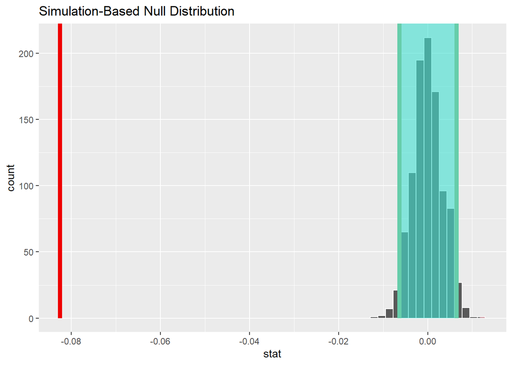

```r
null_dist_x %>%
  visualize() +                                       # method 없음
  shade_p_value(obs_stat = x_bar,
                direction = "two-sided") +            # x_bar
  shade_confidence_interval(endpoints = null_dist_ci) # CI
```

# p_value

```r
null_dist_x %>%
  get_p_value(obs_stat = x_bar,
              direction = "two-sided") %>%
  print()
```

```
## # A tibble: 1 x 1
##   p_value
##     <dbl>
## 1       0
```

# 8.2 t값을 이용한 검정그래프

# t_cal 계산

```r
t_cal <- brain_tb %>%
  specify(response = 차이) %>%
  hypothesize(null = "point",         # hypothesize 필요
              mu = 0) %>%
  calculate(stat = "t") %>%           # stat = "t"
  print()
```

```
## Response: 차이 (numeric)
## Null Hypothesis: point
## # A tibble: 1 x 1
##    stat
##   <dbl>
## 1 -24.4
```

# Bootstrapping을 이용한 귀무가설 분포 생성

```r
set.seed(123)
null_dist_t <- brain_tb %>%
  specify(response = 차이) %>%
  hypothesize(null = "point",
              mu = 0) %>%
  generate(reps = 1000,
           type = "bootstrap") %>%
  calculate(stat = "t") %>%
  print()
```

```
## Response: 차이 (numeric)
## Null Hypothesis: point
## # A tibble: 1,000 x 2
##    replicate    stat
##        <int>   <dbl>
##  1         1 -0.989
##  2         2  1.33
##  3         3  0.303
##  4         4 -0.854
##  5         5  0.369
##  6         6  0.0218
##  7         7  0.840
##  8         8  1.35
##  9         9  0.105
## 10        10 -1.51
## # ... with 990 more rows
```

# 신뢰구간 생성

```r
null_dist_ci <- null_dist_t %>%
  get_ci(level = 0.95,
         type = "percentile") %>%
  print()
```

```
## # A tibble: 1 x 2
##   lower_ci upper_ci
##      <dbl>    <dbl>
## 1    -1.88     1.92
```

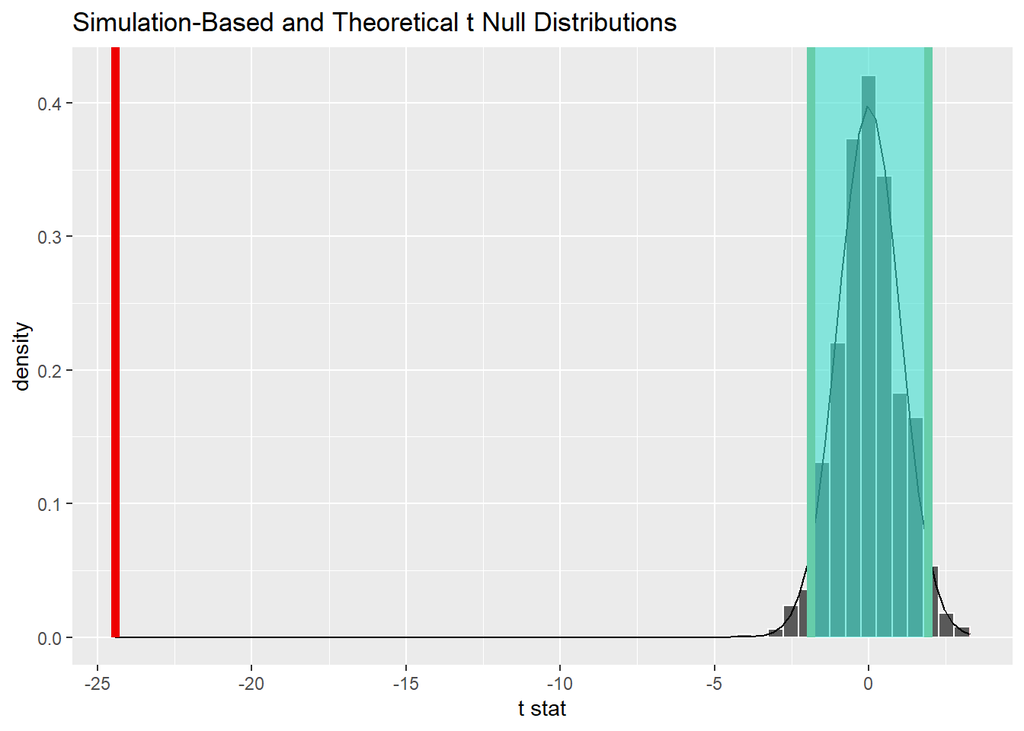

```r
null_dist_t %>%
  visualize(method = "both") +           #method = "both": 이론분포+boot분포
  shade_p_value(obs_stat = t_cal,
                direction = "two-sided") +
  shade_confidence_interval(endpoints = null_dist_ci)
```

## 연습문제5

## K식품에서는 햄버거의 칼로리를 연구하고 있다.

## 햄버거의 칼로리가 500kcal 보다 작다고 말 할 수 있는가?

# 1.기본 package 설정

# 1.1 library 로드

```r
library(tidyverse)
library(tidymodels)
library(rstatix)
library(skimr)
```

# 2.데이터 불러오기

```r
cal_tb <- read_csv('data5.csv',
                   col_names = TRUE,
                   locale=locale('ko', encoding='euc-kr'), # 한글
                   na=".") %>%
  round(2) %>%                  # 소수점 2자리로 반올림
  mutate_if(is.character, as.factor)
str(cal_tb)
```

```
## tibble [40 x 1] (S3: tbl_df/tbl/data.frame)
##  $ cscore: num [1:40] 509 481 501 502 498 503 497 489 504 502 ...
```

```r
glimpse(cal_tb)
```

```
## Rows: 40
## Columns: 1
## $ cscore <dbl> 509, 481, 501, 502, 498, 503, 497, 489, 504, 502, 499, 510, 504~
```

```r
cal_tb
```

```
## # A tibble: 40 x 1
##    cscore
##     <dbl>
##  1    509
##  2    481
##  3    501
##  4    502
##  5    498
##  6    503
##  7    497
##  8    489
##  9    504
## 10    502
## # ... with 30 more rows
```

# 3.기본통계치 확인

```r
skim(cal_tb) # mean -> 498
```

Data summary

| Name | cal_tb |
| --- | --- |
| Number of rows | 40 |
| Number of columns | 1 |
| _______________________ |  |
| Column type frequency: |  |
| numeric | 1 |
| ________________________ |  |
| Group variables | None |

**Variable type: numeric**

| skim_variable | n_missing | complete_rate | mean | sd | p0 | p25 | p50 | p75 | p100 | hist |
| --- | --- | --- | --- | --- | --- | --- | --- | --- | --- | --- |
| cscore | 0 | 1 | 498.18 | 6.37 | 476 | 496.75 | 499.5 | 502 | 510 | ▁▁▂▇▁ |

```r
cal_tb %>%
  get_summary_stats(cscore)
```

```
## # A tibble: 1 x 13
##   variable     n   min   max median    q1    q3   iqr   mad  mean    sd    se
##   <chr>    <dbl> <dbl> <dbl>  <dbl> <dbl> <dbl> <dbl> <dbl> <dbl> <dbl> <dbl>
## 1 cscore      40   476   510   500.  497.   502  5.25  3.71  498.  6.37  1.01
## # ... with 1 more variable: ci <dbl>
```

# 4.그래프 그리기(박스그래프,히스토그램)

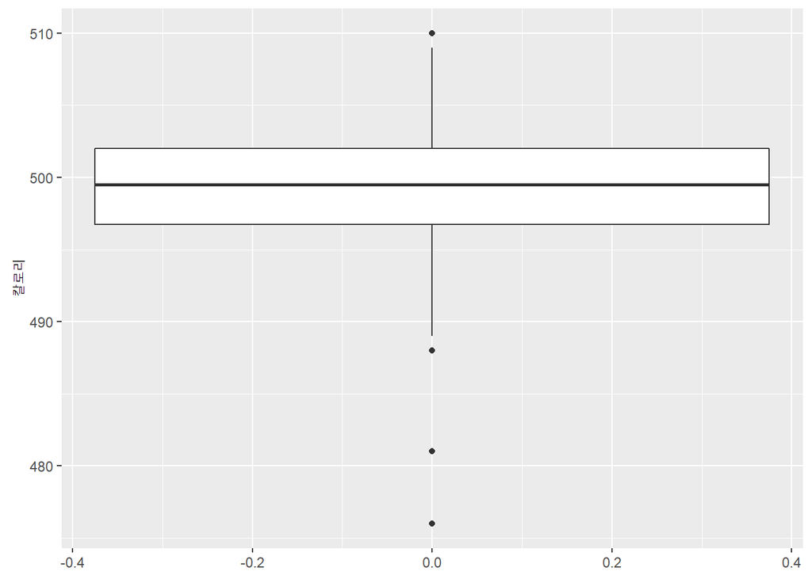

```r
cal_tb %>%
  ggplot(aes(y = cscore)) +
  geom_boxplot() +
  labs(y = "칼로리")
```

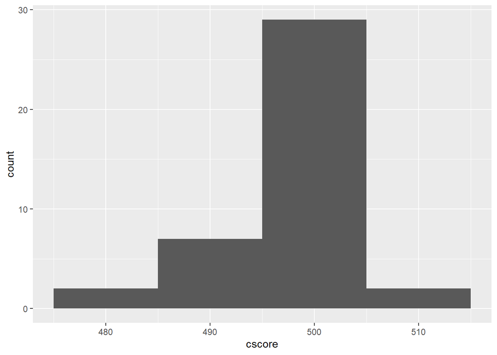

```r
cal_tb %>%
  ggplot(mapping = aes(x = cscore)) +
  geom_histogram(binwidth = 10) +
  coord_cartesian()
```

# 5.이상치 제거

# 이상치 확인

```r
cal_tb %>%
  identify_outliers(cscore)
```

```
## # A tibble: 4 x 3
##   cscore is.outlier is.extreme
##    <dbl> <lgl>      <lgl>
## 1    481 TRUE       FALSE
## 2    510 TRUE       FALSE
## 3    476 TRUE       TRUE
## 4    488 TRUE       FALSE
```

# 이상치 제거

```r
cal_tb <- cal_tb %>%
  filter(!(cscore <= 489 | cscore >= 510))
```

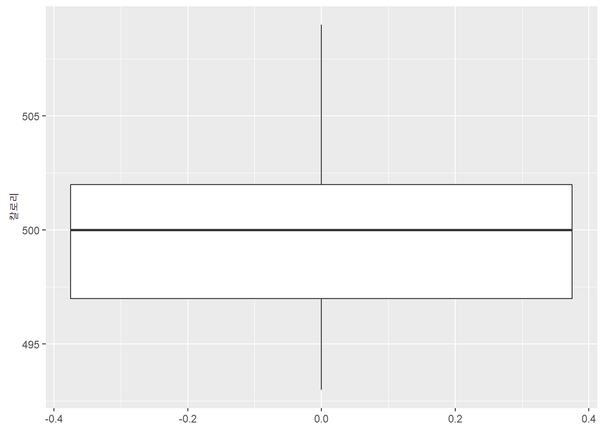

```r
cal_tb %>%
  ggplot(aes(y = cscore)) +
  geom_boxplot() +
  labs(y = "칼로리")
```

# 6.정규분포 검정

```r
cal_tb %>%
  shapiro_test(cscore)
```

```
## # A tibble: 1 x 3
##   variable statistic     p
##   <chr>        <dbl> <dbl>
## 1 cscore       0.967 0.376
```

# 7.통계분석

# two-sided test: alternative = c(“two.sided”)

# right-sided test: alternative = c(“greater”)

# left-sided test: alternative = c(“less”)

```r
cal_tb %>%
  t_test(formula = cscore ~ 1,
         alternative = "less", # 가설이 '작다고 말 할 수 있는가?' 이므로 less 설정
         mu = 500.0,  #  평균 칼로리 500칼로리
         conf.level = 0.95,
         detailed = TRUE)
```

```
## # A tibble: 1 x 12
##   estimate .y.    group1 group2       n statistic     p    df conf.low conf.high
## *    <dbl> <chr>  <chr>  <chr>    <int>     <dbl> <dbl> <dbl>    <dbl>     <dbl>
## 1     500. cscore 1      null mo~    35    -0.831 0.206    34     -Inf      501.
## # ... with 2 more variables: method <chr>, alternative <chr>
```

# Cohen’s d(effect size)

# 0.2 (small effect), 0.5 (moderate effect) and 0.8 (large effect)

```r
cal_tb %>%
  cohens_d(formula = cscore ~ 1,
           mu = 500.0)
```

```
## # A tibble: 1 x 6
##   .y.    group1 group2     effsize     n magnitude
## * <chr>  <chr>  <chr>        <dbl> <int> <ord>
## 1 cscore 1      null model  -0.140    35 negligible
```

# negligible 차이가 없다.

# 8.추론(infer)을 이용한 가설검정 및 그래프

# p.21 설명

# 8.1 표본평균(x)을 이용한 검정그래프

# 표본평균(x) 계산

```r
x_bar <- cal_tb %>%
  specify(response = cscore) %>%    # hypothesize 없음
  calculate(stat = "mean") %>%      # stat = "mean"
  print()
```

```
## Response: cscore (numeric)
## # A tibble: 1 x 1
##    stat
##   <dbl>
## 1  500.
```

# Bootstrapping을 이용한 귀무가설 분포 생성

```r
set.seed(123)
null_dist_x <- cal_tb %>%
  specify(response = cscore) %>%
  hypothesize(null = "point",
              mu = 500) %>%
  generate(reps = 1000,
           type = "bootstrap") %>%
  calculate(stat = "mean") %>%
  print()
```

```
## Response: cscore (numeric)
## Null Hypothesis: point
## # A tibble: 1,000 x 2
##    replicate  stat
##        <int> <dbl>
##  1         1  501.
##  2         2  499.
##  3         3  500.
##  4         4  500.
##  5         5  500.
##  6         6  499.
##  7         7  499.
##  8         8  499.
##  9         9  500.
## 10        10  500.
## # ... with 990 more rows
```

# 신뢰구간 생성

```r
null_dist_ci <- null_dist_x %>%
  get_ci(level = 0.95,
         type = "percentile") %>%
  print()
```

```
## # A tibble: 1 x 2
##   lower_ci upper_ci
##      <dbl>    <dbl>
## 1     499.     501.
```

# 그래프 그리기

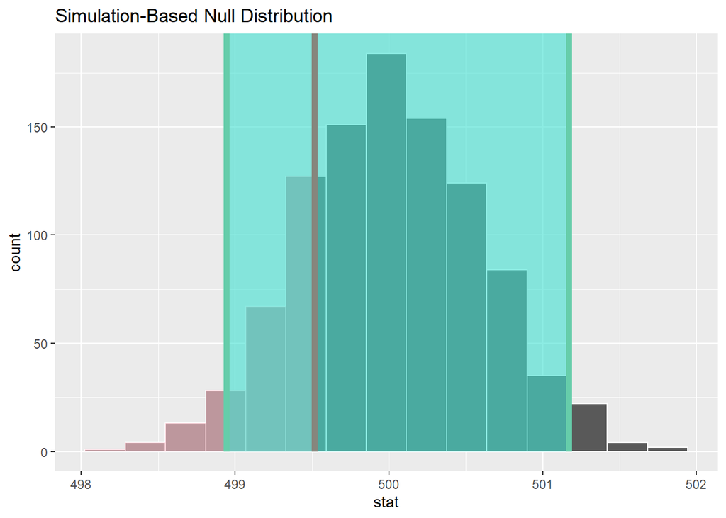

```r
null_dist_x %>%
  visualize() +                                       # method 없음
  shade_p_value(obs_stat = x_bar,
                direction = "less") +            # x_bar
  shade_confidence_interval(endpoints = null_dist_ci) # CI
```

# p_value

```r
null_dist_x %>%
  get_p_value(obs_stat = x_bar,
              direction = "less") %>%
  print()
```

```
## # A tibble: 1 x 1
##   p_value
##     <dbl>
## 1   0.207
```

# 8.2 t값을 이용한 검정그래프

# t_cal 계산

```r
t_cal <- cal_tb %>%
  specify(response = cscore) %>%
  hypothesize(null = "point",         # hypothesize 필요
              mu = 500) %>%
  calculate(stat = "t") %>%           # stat = "t", 평균과 비교할때도 t검정
  print()
```

```
## Response: cscore (numeric)
## Null Hypothesis: point
## # A tibble: 1 x 1
##     stat
##    <dbl>
## 1 -0.831
```

# Bootstrapping을 이용한 귀무가설 분포 생성

```r
set.seed(123)
null_dist_t <- cal_tb %>%
  specify(response = cscore) %>%
  hypothesize(null = "point",
              mu = 500) %>%
  generate(reps = 1000,
           type = "bootstrap") %>%
  calculate(stat = "t") %>%
  print()
```

```
## Response: cscore (numeric)
## Null Hypothesis: point
## # A tibble: 1,000 x 2
##    replicate    stat
##        <int>   <dbl>
##  1         1  1.85
##  2         2 -1.65
##  3         3  0.0455
##  4         4 -0.544
##  5         5 -0.354
##  6         6 -1.34
##  7         7 -1.06
##  8         8 -1.08
##  9         9 -0.982
## 10        10 -0.799
## # ... with 990 more rows
```

# 신뢰구간 생성

```r
null_dist_ci <- null_dist_t %>%
  get_ci(level = 0.95,
         type = "percentile") %>%
  print()
```

```
## # A tibble: 1 x 2
##   lower_ci upper_ci
##      <dbl>    <dbl>
## 1    -2.07     1.94
```

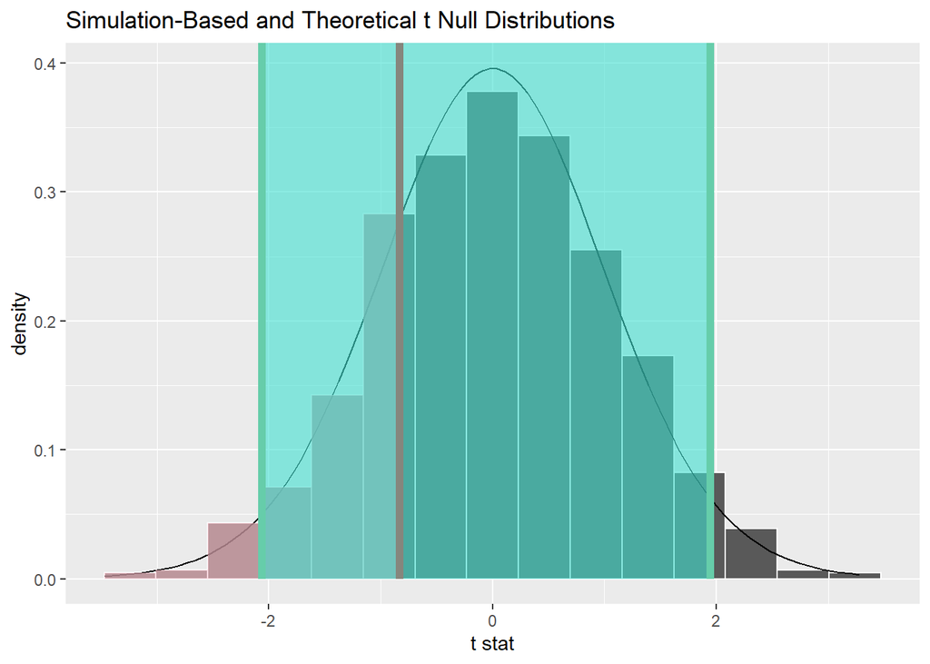

```r
null_dist_t %>%
  visualize(method = "both") +           #method = "both": 이론분포+boot분포
  shade_p_value(obs_stat = t_cal,
                direction = "less") +
  shade_confidence_interval(endpoints = null_dist_ci)
```